# Imports

```python
#import necessary libraries

import pandas as pd
import numpy as np
import optuna
import matplotlib.pyplot as plt
import seaborn as sns
import torch
import tensorflow as tf
import xgboost as xgb
import pickle

from pytorch_tabnet.tab_model import TabNetClassifier
from sklearn.model_selection import train_test_split
from sklearn.preprocessing import Normalizer,StandardScaler,MinMaxScaler
from sklearn.metrics import log_loss,f1_score,accuracy_score, classification_report
from xgboost import XGBClassifier
from keras.callbacks import EarlyStopping, ReduceLROnPlateau
from sklearn.linear_model import LogisticRegression
from sklearn.preprocessing import LabelEncoder
from optuna.pruners import HyperbandPruner, MedianPruner
from sklearn.linear_model import LogisticRegression
from typing import Union, List

# Randomiztion control for tensorflow packages
tf.random.set_seed(0)
np.random.seed(0)
```

```
2023-08-08 14:36:54.027580: I tensorflow/core/platform/cpu_feature_guard.cc:182] This TensorFlow binary is optimized to use available CPU instructions in performance-critical operations.
To enable the following instructions: SSE4.1 SSE4.2 AVX AVX2 FMA, in other operations, rebuild TensorFlow with the appropriate compiler flags.
```

```python
'''#Import and append all 4 csv files. This implementation is both time and memory efficient
file_names = ['mvt_data1.csv', 'mvt_data2.csv', 'mvt_data3.csv', 'mvt_data4.csv']
dfs = []

for file in file_names:
    df = pd.read_csv(file)
    dfs.append(df)

all_data = pd.concat(dfs, ignore_index=True)'''
```

```
"#Import and append all 4 csv files. This implementation is both time and memory efficient \nfile_names = ['mvt_data1.csv', 'mvt_data2.csv', 'mvt_data3.csv', 'mvt_data4.csv']\ndfs = []\n\nfor file in file_names:\n    df = pd.read_csv(file)\n    dfs.append(df)\n\nall_data = pd.concat(dfs, ignore_inde…
```

# Data Loading

```python
#Import csv files
mvt1 = pd.read_csv('MVT all clients clean.csv')
fgpc = pd.read_csv('final graph point clean battery study add on.csv')
```

# Data Cleaning and Preprocessing Functions

## Binary Decision Mapping Function

```python
#This function will be used later to re-map battery decision
good = ['GOOD BATTERY','GOOD RECHARGE']
bad = ['REPLACE BATTERY','BADCELL SHORT REPLACE']

def batterydecision(status):
    if status in good:
        return 'GOOD BATTERY'
    elif status in bad:
        return 'BAD BATTERY'
    else:
        return status
```

```python
#Define Column Names: Will be appled later
column_names = ['Test_Record_Detail_Id', 'Voltage', 'Rated', 'Measured',
                'Battery_Decision', 'Min', 'Max', 'Standard_Deviation', 'Average',
                'Median', 'Bounce_Back', 'Drop', 'Slope_Bounce_Back', 'Slope_Drop',
                'Min_Volt_Below_19', 'Max_Volt_19_Above','Conductance']
```

## Multiclass Decision Mapping Dictionary

```python
#Mapping to convert dummy to real values of Battery Decision
#Define values for battery decision: Will be applied later
bd_map = { 0:'GOOD BATTERY',
           1: 'GOOD RECHARGE',
           2: 'MARGINAL RECHARGE',
           3: 'MARGINAL',
           4: 'CHARGE & RETEST',
           5: 'REPLACE BATTERY',
           6: 'BADCELL SHORT REPLACE',
           7: 'REMOTE POST',
           8: ' SIDE POST',
           11: ' FROZEN BATTERY',
           15: 'INVALID TEST',
           26: 'CHECK PACK',
           16: 'ABORTED/24V',
           23: 'SYSTEM NOISE',
           30: 'DECISION NOT REACHED',
           33: 'REST & RETEST',
           126: 'NO DECISION',
           255: 'No Decision'}
```

## Outlier Removal Function

```python
#Function for outlier removal will be used later in the code

def remove_outliers(df):
    # Selecting data that Voltage less than 30V
    df = df.loc[df['Voltage'] < 16]

    # df = df.loc[df['Voltage'] >= 11.4]

    # Selecting data that average equal or less than 18
    df = df.loc[df['Average'] <= 18]

    # Selecting data that min equal or less than 12
    df = df.loc[df['Min'] <= 12]

    # Selecting data that max equal or less than 16
    df = df.loc[df['Max'] <= 16]

    # Selecting data that bounce back equal or less than 16
    df = df.loc[df['Bounce_Back'] <= 16]

    # Selecting data that slope bounce back from the range [-.5;.5]
    df = df.loc[(df['Slope_Bounce_Back'] <= 0.5) & (df['Slope_Bounce_Back'] >= 0.005)]

    # Selecting data that slope drop from the range [-2;2]
    df = df.loc[(df['Slope_Drop'] <= 2) & (df['Slope_Drop'] >= -2)]

    return df
```

## Feature Egineering Function

```python
#This function calculates conductance and adds column to dataframe. Then it updates the column names, and sets the datatype each feature
def clean_data(df):

    #Add Conductance column
    df['Conductance'] = df.Measured/df.Rated

    # Rename columns using the provided column_names list
    df = df.rename(columns=dict(zip(df.columns, column_names)))

    # Reorder the DataFrame using the desired column order
    df = df[['Test_Record_Detail_Id', 'Voltage', 'Rated', 'Measured','Conductance',
                'Battery_Decision', 'Min', 'Max', 'Standard_Deviation', 'Average',
                'Median', 'Bounce_Back', 'Drop', 'Slope_Bounce_Back', 'Slope_Drop',
                'Min_Volt_Below_19', 'Max_Volt_19_Above']]


    #Downcasting: Downcasting is the prcess of casting values to datatypes with lower byes. Somtimes the extra bytes are not used
    #and end up using more memory than needed. Downcasting can lower the size of dataframes, and help speed up processes later on.

    df[['Voltage','Min','Max','Median','Bounce_Back','Drop','Min_Volt_Below_19','Max_Volt_19_Above']] = df[['Voltage','Min','Max','Median','Bounce_Back','Drop','Min_Volt_Below_19','Max_Volt_19_Above']].astype('float32')
    df[['Test_Record_Detail_Id']]= df[['Test_Record_Detail_Id']].astype('int32')
    df[['Rated','Measured']]= df[['Rated','Measured']].astype('int16')
    df[['Battery_Decision']] = df[['Battery_Decision']].astype('category')


    processed_data = remove_outliers(df)

    return processed_data
```

```python
#Apply data cleaning function
mvt1_clean = clean_data(mvt1)
fgpc_clean = clean_data(fgpc)
```

```python
# Keep 0, 1, 5, 6
mvt1_clean.Battery_Decision.value_counts()
```

```
0    807493
5    584027
1    438878
6     31812
Name: Battery_Decision, dtype: int64
```

```python
# Keep 0, 1, 5, 6
fgpc_clean.Battery_Decision.value_counts()
```

```
0    156
1    119
5     84
4     20
6      1
Name: Battery_Decision, dtype: int64
```

```python
# 3. Check for Missing Values
missing_values1 = mvt1_clean.isnull().sum()
missing_values2 = fgpc_clean.isnull().sum()

#Remove rows with missing values
mvt1_clean = mvt1_clean.dropna()
fgpc_clean = fgpc_clean.dropna()


# 4. Data Distribution of the Target Variable
target_distribution1 = mvt1_clean.Battery_Decision.value_counts()
target_distribution2 = fgpc_clean.Battery_Decision.value_counts()
```

```python
print(f"Missing Values:\n{missing_values1}\n\nTarget Distribution:\n{target_distribution1}")
```

```
Missing Values:
Test_Record_Detail_Id        0
Voltage                      0
Rated                        0
Measured                     0
Conductance              74911
Battery_Decision             0
Min                          0
Max                          0
Standard_Deviation           0
Average                      0
Median                       0
Bounce_Back                  0
Drop                         0
Slope_Bounce_Back            0
Slope_Drop                   0
Min_Volt_Below_19            0
Max_Volt_19_Above            0
dtype: int64

Target Distribution:
0    732583
5    584026
1    438878
6     31812
Name: Battery_Decision, dtype: int64
```

```python
print(f"Missing Values:\n{missing_values2}\n\nTarget Distribution:\n{target_distribution2}")
```

```
Missing Values:
Test_Record_Detail_Id    0
Voltage                  0
Rated                    0
Measured                 0
Conductance              0
Battery_Decision         0
Min                      0
Max                      0
Standard_Deviation       0
Average                  0
Median                   0
Bounce_Back              0
Drop                     0
Slope_Bounce_Back        0
Slope_Drop               0
Min_Volt_Below_19        0
Max_Volt_19_Above        0
dtype: int64

Target Distribution:
0    156
1    119
5     84
4     20
6      1
Name: Battery_Decision, dtype: int64
```

```python
#Drop Rows with infinite values
mvt1_clean = mvt1_clean[~np.isinf(mvt1_clean['Conductance'])]
fgpc_clean = fgpc_clean[~np.isinf(fgpc_clean['Conductance'])]
```

## Map And Remove Function

```python
def map_and_remove(df):
    # Replace numerical classes 0,1,4,5,6 with correspoinding decision label
    df['Battery_Decision'] = df['Battery_Decision'].map(bd_map)
    # Regroup categories into Good Battery and Bad Battery
    df.loc[:, 'Battery_Decision'] = df.loc[:, 'Battery_Decision'].apply(batterydecision)

    #Keep Only Class GOOD BATTERY  and Class BAD BATTERY
    df = df.query('(Battery_Decision == "GOOD BATTERY") | (Battery_Decision == "BAD BATTERY")')

    return df

#Return mapped and cleaned data
mvt1_clean = map_and_remove(mvt1_clean)
fgpc_clean = map_and_remove(fgpc_clean)
```

```python
#Turn y into numpy array
y1 = mvt1_clean.Battery_Decision.to_numpy()
y2 = fgpc_clean.Battery_Decision.to_numpy()
```

```python
mvt1_clean.describe()
```

|  | Test_Record_Detail_Id | Voltage | Rated | Measured | Conductance | Min | Max | Standard_Deviation | Average | Median | Bounce_Back | Drop | Slope_Bounce_Back | Slope_Drop | Min_Volt_Below_19 | Max_Volt_19_Above |
| --- | --- | --- | --- | --- | --- | --- | --- | --- | --- | --- | --- | --- | --- | --- | --- | --- |
| count | 1.787271e+06 | 1.787271e+06 | 1.787271e+06 | 1.787271e+06 | 1.787271e+06 | 1.787271e+06 | 1.787271e+06 | 1.787271e+06 | 1.787271e+06 | 1.787271e+06 | 1.787271e+06 | 1.787271e+06 | 1.787271e+06 | 1.787271e+06 | 1.787271e+06 | 1.787271e+06 |
| mean | 1.992919e+08 | 1.253351e+01 | 6.231677e+02 | 5.768674e+02 | 9.941337e-01 | 8.104712e+00 | 1.228961e+01 | 8.128497e-01 | 1.036738e+01 | 1.037002e+01 | 3.646370e+00 | 4.007642e+00 | 2.319333e-02 | -5.993289e-01 | 8.248718e+00 | 1.189509e+01 |
| std | 3.604167e+07 | 5.213792e-01 | 1.151458e+02 | 9.890280e+02 | 1.815700e+00 | 1.728116e+00 | 1.172094e+00 | 4.180085e-01 | 1.493214e+00 | 1.578291e+00 | 1.187931e+00 | 1.169328e+00 | 2.392102e-02 | 1.830312e-01 | 1.547612e+00 | 1.253387e+00 |
| min | 1.032263e+08 | 1.000000e-02 | 8.000000e+01 | -3.270600e+04 | 0.000000e+00 | 0.000000e+00 | 6.500000e-01 | 7.381669e-02 | 4.967391e-02 | 0.000000e+00 | 1.000000e-02 | 1.000000e-02 | 5.000000e-03 | -2.000000e+00 | 0.000000e+00 | 1.000000e-02 |
| 25% | 1.721876e+08 | 1.240000e+01 | 5.500000e+02 | 4.220000e+02 | 7.166667e-01 | 7.670000e+00 | 1.228000e+01 | 5.845186e-01 | 1.030232e+01 | 1.030000e+01 | 2.910000e+00 | 3.300000e+00 | 1.347059e-02 | -6.983333e-01 | 7.760000e+00 | 1.185000e+01 |
| 50% | 2.065959e+08 | 1.262000e+01 | 6.000000e+02 | 5.600000e+02 | 9.300000e-01 | 8.540000e+00 | 1.249000e+01 | 7.087000e-01 | 1.081038e+01 | 1.083000e+01 | 3.530000e+00 | 3.870000e+00 | 1.831395e-02 | -5.900000e-01 | 8.570000e+00 | 1.212000e+01 |
| 75% | 2.274219e+08 | 1.281000e+01 | 7.000000e+02 | 6.970000e+02 | 1.109333e+00 | 9.130000e+00 | 1.268000e+01 | 8.806414e-01 | 1.111166e+01 | 1.115000e+01 | 4.240000e+00 | 4.550000e+00 | 2.699366e-02 | -4.900000e-01 | 9.160000e+00 | 1.237000e+01 |
| max | 2.534552e+08 | 1.591000e+01 | 3.000000e+03 | 3.276000e+04 | 2.345214e+02 | 1.200000e+01 | 1.600000e+01 | 6.233117e+00 | 1.318727e+01 | 1.372000e+01 | 1.501000e+01 | 1.444000e+01 | 5.000000e-01 | -6.250000e-04 | 1.285000e+01 | 1.600000e+01 |

```python
mvt1_clean = mvt1_clean.drop(columns =['Battery_Decision','Test_Record_Detail_Id'])
fgpc_clean =fgpc_clean.drop(columns =['Battery_Decision','Test_Record_Detail_Id'])

#Applay MinMix Scaler
minmax = MinMaxScaler()
mvt1_clean[mvt1_clean.columns] = minmax.fit_transform(mvt1_clean)
fgpc_clean[fgpc_clean.columns] = minmax.fit_transform(fgpc_clean)
```

```python
# Assuming 'Battery_Decision' is the categorical column to be encoded
label_encoder = LabelEncoder()
mvt1_clean['Battery_Decision'] = label_encoder.fit_transform(y1)
fgpc_clean['Battery_Decision'] = label_encoder.fit_transform(y2)

''' 0 == Bad Battery
    1 == Good Battery'''

#Separate X and Y
y1 = mvt1_clean['Battery_Decision']
y2 = fgpc_clean['Battery_Decision']

X1 = mvt1_clean.drop(columns= 'Battery_Decision')
X2 = fgpc_clean.drop(columns= 'Battery_Decision')
```

```python
label_encoder.inverse_transform([0,1])
```

```
array(['BAD BATTERY', 'GOOD BATTERY'], dtype=object)
```

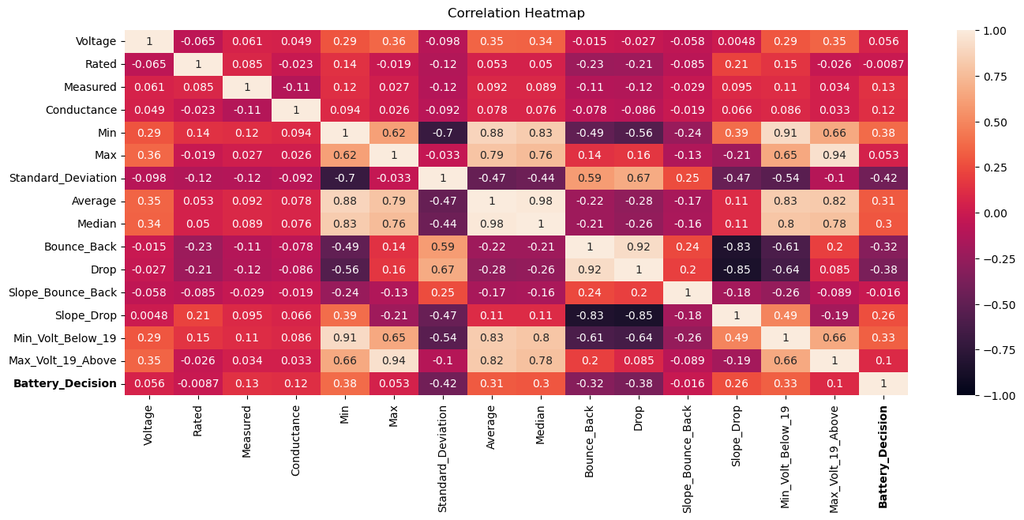

```python
# Assuming you already have the processed_data DataFrame and other code for generating the heatmap
plt.figure(figsize=(16, 6))

# Create the correlation heatmap and store the 'ax' object
ax = sns.heatmap(mvt1_clean.corr(numeric_only=True), vmin=-1, vmax=1, annot=True)

# Find the label 'battery decision' in the columns of the DataFrame
battery_decision_label = 'Battery_Decision'
battery_decision_index = mvt1_clean.columns.to_list().index(battery_decision_label)

# Modify the font properties to make the label bold
ax.get_yticklabels()[battery_decision_index].set_weight('bold')
ax.get_xticklabels()[battery_decision_index].set_weight('bold')

# Set the title for the heatmap
ax.set_title('Correlation Heatmap', fontdict={'fontsize': 12}, pad=12)

# Show the heatmap
plt.show()
```

Based on the results of the Correlation Heatmap, one can see that certain features are very highly correlated such as Median and Average, Max and Max_Volt_19_Above, and Drop and Bounce_Back. Removeing one more of these features might help improve model preformance as highly correlated features can lead the model to overfit, especially if the two features aren't independned.

```python
X_train, X_temp, y_train,y_temp = train_test_split(X1,y1, stratify=y1, test_size= .30, random_state=42)
X_val, X_test, y_val,y_test = train_test_split(X_temp,y_temp, stratify=y_temp, test_size= .50, random_state=42)
```

```python
X_train = X_train.append(X2)
y_train = y_train.append(y2)

X_train.reset_index(drop=True, inplace=True)
y_train.reset_index(drop=True, inplace=True)
```

```python
X_train.head(10)
```

|  | Voltage | Rated | Measured | Conductance | Min | Max | Standard_Deviation | Average | Median | Bounce_Back | Drop | Slope_Bounce_Back | Slope_Drop | Min_Volt_Below_19 | Max_Volt_19_Above |
| --- | --- | --- | --- | --- | --- | --- | --- | --- | --- | --- | --- | --- | --- | --- | --- |
| 0 | 0.785535 | 0.229452 | 0.510647 | 0.004116 | 0.666667 | 0.781108 | 0.131649 | 0.821997 | 0.791545 | 0.304000 | 0.320166 | 0.078671 | 0.614359 | 0.622568 | 0.785491 |
| 1 | 0.793082 | 0.250000 | 0.510127 | 0.003632 | 0.717500 | 0.766775 | 0.099055 | 0.775952 | 0.742711 | 0.242667 | 0.263340 | 0.049848 | 0.728085 | 0.670039 | 0.766104 |
| 2 | 0.808805 | 0.195205 | 0.505973 | 0.002742 | 0.644167 | 0.751140 | 0.163415 | 0.791710 | 0.745627 | 0.283333 | 0.303534 | 0.048048 | 0.634365 | 0.601556 | 0.749218 |
| 3 | 0.782390 | 0.195205 | 0.510723 | 0.004782 | 0.719167 | 0.766775 | 0.084608 | 0.853120 | 0.825073 | 0.242000 | 0.261261 | 0.019431 | 0.685214 | 0.671595 | 0.766729 |
| 4 | 0.791195 | 0.229452 | 0.503376 | 0.001410 | 0.236667 | 0.725081 | 0.212046 | 0.690306 | 0.685496 | 0.234667 | 0.168399 | 0.061932 | 0.878274 | 0.642023 | 0.736085 |
| 5 | 0.807547 | 0.143836 | 0.507164 | 0.004230 | 0.733333 | 0.776547 | 0.081166 | 0.843807 | 0.818878 | 0.242000 | 0.259875 | 0.010497 | 0.765239 | 0.684825 | 0.777361 |
| 6 | 0.801887 | 0.160959 | 0.510952 | 0.005768 | 0.790000 | 0.779153 | 0.078098 | 0.870324 | 0.838921 | 0.183333 | 0.216216 | 0.051171 | 0.776671 | 0.737743 | 0.764853 |
| 7 | 0.790566 | 0.133562 | 0.508905 | 0.005534 | 0.699167 | 0.768078 | 0.093706 | 0.823408 | 0.790816 | 0.256000 | 0.279279 | 0.052121 | 0.663541 | 0.652918 | 0.764853 |
| 8 | 0.812579 | 0.160959 | 0.508768 | 0.004659 | 0.756667 | 0.794137 | 0.101102 | 0.825077 | 0.795189 | 0.216667 | 0.259875 | 0.020819 | 0.731657 | 0.706615 | 0.771107 |
| 9 | 0.829560 | 0.116438 | 0.503284 | 0.002457 | 0.448333 | 0.811726 | 0.186188 | 0.576130 | 0.544461 | 0.510000 | 0.534304 | 0.048738 | 0.448712 | 0.418677 | 0.814884 |

# XGBoost Classification Playground

```python
base_xgb = XGBClassifier(random_state = 42)
base_xgb.fit(X_train,y_train,eval_set = [(X_val,y_val)],verbose = 0)
```

```
XGBClassifier(base_score=None, booster=None, callbacks=None,
              colsample_bylevel=None, colsample_bynode=None,
              colsample_bytree=None, early_stopping_rounds=None,
              enable_categorical=False, eval_metric=None, feature_types=None,
              gamma=None, gpu_id=None, grow_policy=None, importance_type=None,
              interaction_constraints=None, learning_rate=None, max_bin=None,
              max_cat_threshold=None, max_cat_to_onehot=None,
              max_delta_step=None, max_depth=None, max_leaves=None,
              min_child_weight=None, missing=nan, monotone_constraints=None,
              n_estimators=100, n_jobs=None, num_parallel_tree=None,
              predictor=None, random_state=42, ...)
```

```python
# Get feature importances
feature_importances = base_xgb.feature_importances_

# Combine feature names and importances
feature_importance_pairs = zip(X_train.columns, feature_importances)

# Sort feature importance pairs based on importance (ascending order)
sorted_feature_importance_pairs = sorted(feature_importance_pairs, key=lambda x: x[1])

# Display the sorted feature importances
for feature, importance in sorted_feature_importance_pairs:
    print(f"{feature}: {importance}")
```

```
Slope_Drop: 0.0033681269269436598
Bounce_Back: 0.004052398260682821
Drop: 0.0041251289658248425
Median: 0.004427636507898569
Min_Volt_Below_19: 0.006413151044398546
Rated: 0.007388368248939514
Standard_Deviation: 0.011490480974316597
Average: 0.01558948028832674
Min: 0.015628470107913017
Max_Volt_19_Above: 0.022938013076782227
Slope_Bounce_Back: 0.02407892420887947
Measured: 0.025009680539369583
Max: 0.040414437651634216
Voltage: 0.21489055454730988
Conductance: 0.6001850962638855
```

## Drop & Train XGB Function

```python
#This function trains an xgboost classifer using either all features, or droping the specified columns. Then print validation and test performance scores\

def train_xgb(drop_columns: Union[List[str], None] = None): #Takes in list of column names to be dropped, or None

    if drop_columns is not None:   #If column(s) names are given, drop columns with matching name from X data, and train
        xgb = XGBClassifier(random_state = 42)
        xgb.fit(X_train.drop(columns=drop_columns),y_train,eval_set = [(X_val.drop(columns=drop_columns),y_val)], verbose = 0 )

        #Print Validation Results
        y_proba_xgb = xgb.predict_proba(X_val.drop(columns=drop_columns))
        y_predict_xgb = xgb.predict(X_val.drop(columns=drop_columns))
        print(f"--(Validation Set: Drop {drop_columns})--\nLog-Loss: {log_loss(y_val.drop(columns=drop_columns), y_proba_xgb)}\nTotal Accuracy:{accuracy_score(y_val.drop(columns=drop_columns), y_predict_xgb)}\n{classification_report(y_val, y_predict_xgb)}")

        # Print Test Results
        y_proba_xgb = xgb.predict_proba(X_test.drop(columns=drop_columns))
        y_predict_xgb = xgb.predict(X_test.drop(columns=drop_columns))
        print(f"--(Test Set: Drop {drop_columns})--\nLog-Loss: {log_loss(y_test.drop(columns=drop_columns), y_proba_xgb)}\nTotal Accuracy:{accuracy_score(y_test.drop(columns=drop_columns), y_predict_xgb)}\n{classification_report(y_test, y_predict_xgb)}")



    else:  #If no columns to drop are give, train model using all the features

        xgb = XGBClassifier(random_state = 42)
        xgb.fit(X_train,y_train,eval_set = [(X_val,y_val)],verbose = 0)

        #Print Validation Results
        y_proba_xgb_val = xgb.predict_proba(X_val)
        y_predict_xgb_val = xgb.predict(X_val)
        print(f"--(Validation Set: All Features)\nLog-Loss: {log_loss(y_val, y_proba_xgb_val)}\nTotal Accuracy:{accuracy_score(y_val, y_predict_xgb_val)}\n{classification_report(y_val, y_predict_xgb_val)}")

        # Print Test Results
        y_proba_xgb_test = xgb.predict_proba(X_test)
        y_predict_xgb_test = xgb.predict(X_test)
        print(f"--(Test Set: All Features)--\nLog-Loss: {log_loss(y_test, y_proba_xgb_test)}\nTotal Accuracy:{accuracy_score(y_test, y_predict_xgb_test)}\n{classification_report(y_test, y_predict_xgb_test)}")

        return y_proba_xgb_val, y_predict_xgb_val,
```

## XGBoost Feature Selection Results

Train different generic XGBoost models, testing the effect of dropping different features. For example, since average and median are very highly correlated,so first we can test to see if dropping either average or median can improve model performance. Then we can check to see if dropping the Slope_Drop feature improves performance since it is the feature with the least importance.

```python
train_xgb(['Median'])
```

```
--(Validation Set: Drop ['Median'])--
Log-Loss: 0.14275168230567453
Total Accuracy:0.9465703809527362
              precision    recall  f1-score   support

           0       0.95      0.89      0.92     92375
           1       0.94      0.98      0.96    175716

    accuracy                           0.95    268091
   macro avg       0.95      0.93      0.94    268091
weighted avg       0.95      0.95      0.95    268091

--(Test Set: Drop ['Median'])--
Log-Loss: 0.14443628107318204
Total Accuracy:0.946816566016763
              precision    recall  f1-score   support

           0       0.95      0.89      0.92     92375
           1       0.94      0.98      0.96    175716

    accuracy                           0.95    268091
   macro avg       0.95      0.93      0.94    268091
weighted avg       0.95      0.95      0.95    268091
```

```python
train_xgb(['Average'])
```

```
--(Validation Set: Drop ['Average'])--
Log-Loss: 0.14284817171016273
Total Accuracy:0.9465442704156425
              precision    recall  f1-score   support

           0       0.95      0.89      0.92     92375
           1       0.94      0.98      0.96    175716

    accuracy                           0.95    268091
   macro avg       0.95      0.93      0.94    268091
weighted avg       0.95      0.95      0.95    268091

--(Test Set: Drop ['Average'])--
Log-Loss: 0.14416206633275147
Total Accuracy:0.9471746533826201
              precision    recall  f1-score   support

           0       0.95      0.89      0.92     92375
           1       0.94      0.98      0.96    175716

    accuracy                           0.95    268091
   macro avg       0.95      0.93      0.94    268091
weighted avg       0.95      0.95      0.95    268091
```

```python
train_xgb(['Slope_Drop']) ##Drop Slop scored the lowest feature importance
```

```
--(Validation Set: Drop ['Slope_Drop'])--
Log-Loss: 0.14257777159607474
Total Accuracy:0.9467643449425754
              precision    recall  f1-score   support

           0       0.95      0.89      0.92     92375
           1       0.94      0.98      0.96    175716

    accuracy                           0.95    268091
   macro avg       0.95      0.93      0.94    268091
weighted avg       0.95      0.95      0.95    268091

--(Test Set: Drop ['Slope_Drop'])--
Log-Loss: 0.14413100729832093
Total Accuracy:0.9469210081651379
              precision    recall  f1-score   support

           0       0.95      0.89      0.92     92375
           1       0.94      0.98      0.96    175716

    accuracy                           0.95    268091
   macro avg       0.95      0.93      0.94    268091
weighted avg       0.95      0.95      0.95    268091
```

```python
train_xgb(['Bounce_Back'])
```

```
--(Validation Set: Drop ['Bounce_Back'])--
Log-Loss: 0.14276537289077965
Total Accuracy:0.9467419644822094
              precision    recall  f1-score   support

           0       0.95      0.89      0.92     92375
           1       0.94      0.98      0.96    175716

    accuracy                           0.95    268091
   macro avg       0.95      0.93      0.94    268091
weighted avg       0.95      0.95      0.95    268091

--(Test Set: Drop ['Bounce_Back'])--
Log-Loss: 0.14433889623364787
Total Accuracy:0.947163463152437
              precision    recall  f1-score   support

           0       0.95      0.89      0.92     92375
           1       0.94      0.98      0.96    175716

    accuracy                           0.95    268091
   macro avg       0.95      0.93      0.94    268091
weighted avg       0.95      0.95      0.95    268091
```

```python
train_xgb(['Drop'])
```

```
--(Validation Set: Drop ['Drop'])--
Log-Loss: 0.1428086583737852
Total Accuracy:0.9466785531778389
              precision    recall  f1-score   support

           0       0.95      0.89      0.92     92375
           1       0.94      0.98      0.96    175716

    accuracy                           0.95    268091
   macro avg       0.95      0.93      0.94    268091
weighted avg       0.95      0.95      0.95    268091

--(Test Set: Drop ['Drop'])--
Log-Loss: 0.14441826212313036
Total Accuracy:0.9470776713877005
              precision    recall  f1-score   support

           0       0.95      0.89      0.92     92375
           1       0.94      0.98      0.96    175716

    accuracy                           0.95    268091
   macro avg       0.95      0.93      0.94    268091
weighted avg       0.95      0.95      0.95    268091
```

```python
train_xgb(['Min_Volt_Below_19'])
```

```
--(Validation Set: Drop ['Min_Volt_Below_19'])--
Log-Loss: 0.14255916007793315
Total Accuracy:0.9466599027942004
              precision    recall  f1-score   support

           0       0.95      0.89      0.92     92375
           1       0.94      0.98      0.96    175716

    accuracy                           0.95    268091
   macro avg       0.95      0.93      0.94    268091
weighted avg       0.95      0.95      0.95    268091

--(Test Set: Drop ['Min_Volt_Below_19'])--
Log-Loss: 0.1440507865891302
Total Accuracy:0.9470105300066023
              precision    recall  f1-score   support

           0       0.95      0.89      0.92     92375
           1       0.94      0.98      0.96    175716

    accuracy                           0.95    268091
   macro avg       0.95      0.93      0.94    268091
weighted avg       0.95      0.95      0.95    268091
```

```python
train_xgb(['Min_Volt_Below_19','Slope_Drop'])
```

```
--(Validation Set: Drop ['Min_Volt_Below_19', 'Slope_Drop'])--
Log-Loss: 0.14265263457248364
Total Accuracy:0.9466673629476559
              precision    recall  f1-score   support

           0       0.95      0.89      0.92     92375
           1       0.94      0.98      0.96    175716

    accuracy                           0.95    268091
   macro avg       0.95      0.93      0.94    268091
weighted avg       0.95      0.95      0.95    268091

--(Test Set: Drop ['Min_Volt_Below_19', 'Slope_Drop'])--
Log-Loss: 0.14434009848509008
Total Accuracy:0.9470851315411558
              precision    recall  f1-score   support

           0       0.95      0.89      0.92     92375
           1       0.94      0.98      0.96    175716

    accuracy                           0.95    268091
   macro avg       0.95      0.93      0.94    268091
weighted avg       0.95      0.95      0.95    268091
```

```python
train_xgb(['Min_Volt_Below_19','Median'])
```

```
--(Validation Set: Drop ['Min_Volt_Below_19', 'Median'])--
Log-Loss: 0.14291217341770038
Total Accuracy:0.946712123868388
              precision    recall  f1-score   support

           0       0.95      0.89      0.92     92375
           1       0.94      0.98      0.96    175716

    accuracy                           0.95    268091
   macro avg       0.95      0.93      0.94    268091
weighted avg       0.95      0.95      0.95    268091

--(Test Set: Drop ['Min_Volt_Below_19', 'Median'])--
Log-Loss: 0.1444103742576103
Total Accuracy:0.9468464066305844
              precision    recall  f1-score   support

           0       0.95      0.89      0.92     92375
           1       0.94      0.98      0.96    175716

    accuracy                           0.95    268091
   macro avg       0.95      0.93      0.94    268091
weighted avg       0.95      0.95      0.95    268091
```

## XGBoos Feature Drop Results

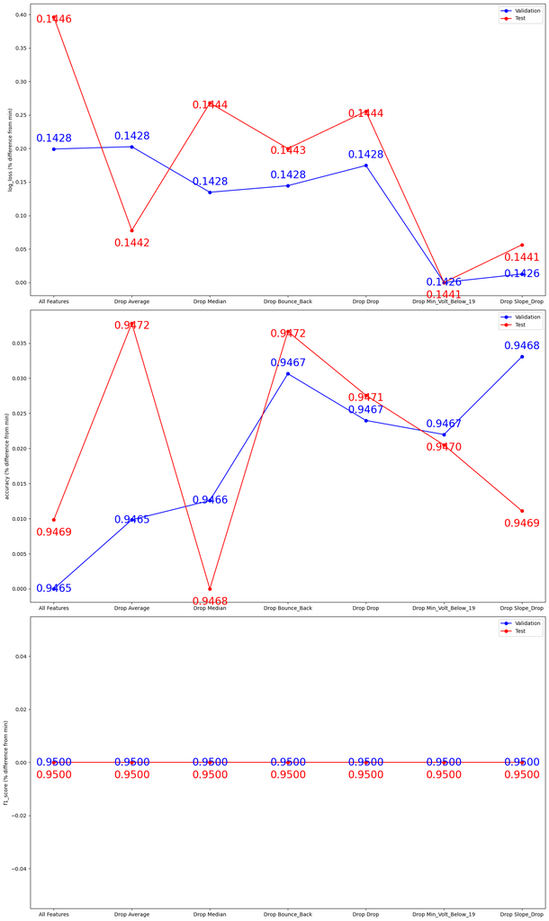

```python
data = {
    "All Features": {
        "validation": {"log_loss": 0.142843, "accuracy": 0.946451, "f1_score": 0.95},
        "test": {"log_loss": 0.144621, "accuracy": 0.946909, "f1_score": 0.95},
    },
    "Drop Average": {
        "validation": {"log_loss": 0.142848, "accuracy": 0.946544, "f1_score": 0.95},
        "test": {"log_loss": 0.144162, "accuracy": 0.947174, "f1_score": 0.95},
    },
    "Drop Median": {
        "validation": {"log_loss": 0.142751, "accuracy": 0.946570, "f1_score": 0.95},
        "test": {"log_loss": 0.144436, "accuracy": 0.946816, "f1_score": 0.95},
    },
    "Drop Bounce_Back": {
        "validation": {"log_loss": 0.142765, "accuracy": 0.946741, "f1_score": 0.95},
        "test": {"log_loss": 0.144338, "accuracy": 0.947163, "f1_score": 0.95},
    },
    "Drop Drop": {
        "validation": {"log_loss": 0.142808, "accuracy": 0.946678, "f1_score": 0.95},
        "test": {"log_loss": 0.144418, "accuracy": 0.947077, "f1_score": 0.95},
    },
    "Drop Min_Volt_Below_19": {
        "validation": {"log_loss": 0.142559, "accuracy": 0.946659, "f1_score": 0.95},
        "test": {"log_loss": 0.144050, "accuracy": 0.947010, "f1_score": 0.95},
    },
    "Drop Slope_Drop": {
        "validation": {"log_loss": 0.142577, "accuracy": 0.946764, "f1_score": 0.95},
        "test": {"log_loss": 0.144131, "accuracy": 0.946921, "f1_score": 0.95},
    },
}

import matplotlib.pyplot as plt
import numpy as np

# Function to scale the values
def scale_values(values):
    min_val = min(values)
    scaled_values = [(val - min_val) / min_val * 100 for val in values]
    return scaled_values

# Create subplots for each metric
fig, ax = plt.subplots(3, 1, figsize=(15, 25))

metrics = ["log_loss", "accuracy", "f1_score"]
for i, metric in enumerate(metrics):
    validation_values = [value["validation"][metric] for value in data.values()]
    test_values = [value["test"][metric] for value in data.values()]

    # Scale the values
    validation_scaled = scale_values(validation_values)
    test_scaled = scale_values(test_values)

    # Create line plot with markers
    ax[i].plot(data.keys(), validation_scaled, marker='o', color="b", label="Validation")
    ax[i].plot(data.keys(), test_scaled, marker='o', color="r", label="Test")

    # Add data labels
    for j, key in enumerate(data.keys()):
        va_validation = "bottom" if validation_scaled[j] > np.mean(validation_scaled) else "top"
        va_test = "bottom" if test_scaled[j] > np.mean(test_scaled) else "top"
        ax[i].annotate(f"{validation_values[j]:.4f}", (key, validation_scaled[j]), textcoords="offset points", xytext=(0,10), ha='center', va=va_validation, fontsize=12, color="b")
        ax[i].annotate(f"{test_values[j]:.4f}", (key, test_scaled[j]), textcoords="offset points", xytext=(0,-15), ha='center', va=va_test, fontsize=12, color="r")

    ax[i].set_ylabel(f"{metric} (% difference from min)")
    ax[i].legend()

plt.tight_layout()
plt.show()
```

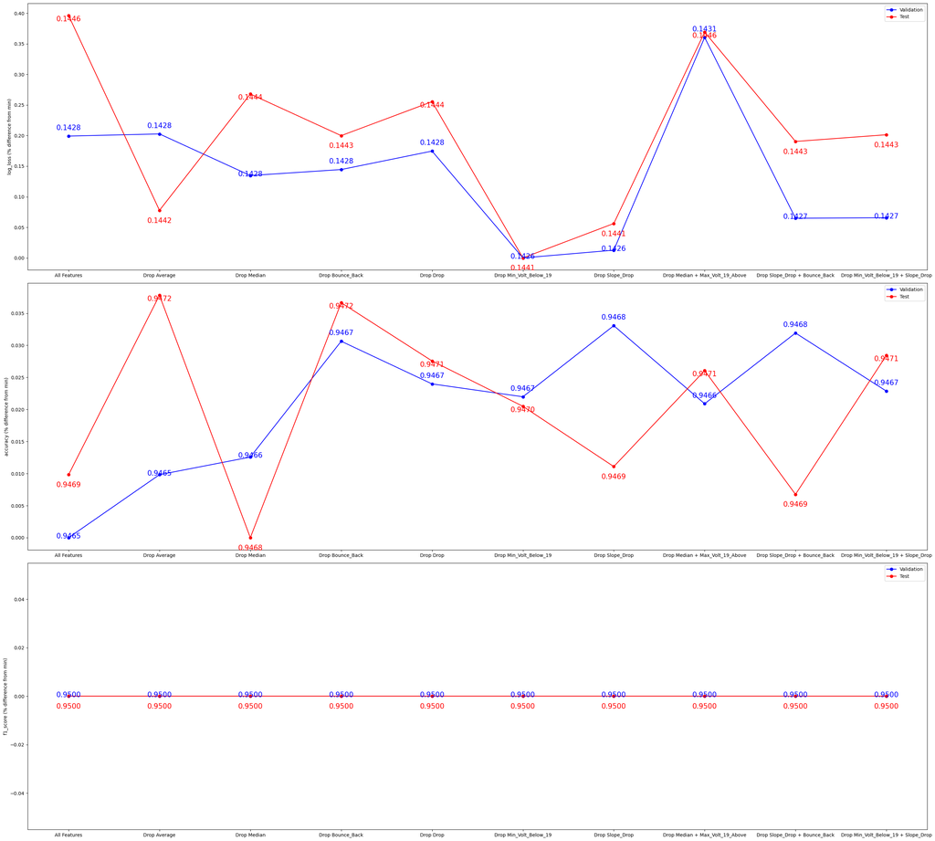

```python
'''

Based on the results so far, we can see that dropping either the Average, Median, or Slope_Drop will increase model performance just slightly.
Although dropping any single one of those columns increases overall performance, the features that increases performance the most when dropped individually are Slop_Drop
and Min_Volt_Below_19. Dropping Min_Volt_Below_19 yeilds a lower logloss but also lowers accuracy very slighly (neglegable?).
We will now test to see if dropping a combination of two or more features can help improve the model.

'''

import matplotlib.pyplot as plt
import numpy as np

data = {
    "All Features": {
        "validation": {"log_loss": 0.142843, "accuracy": 0.946451, "f1_score": 0.95},
        "test": {"log_loss": 0.144621, "accuracy": 0.946909, "f1_score": 0.95},
    },
    "Drop Average": {
        "validation": {"log_loss": 0.142848, "accuracy": 0.946544, "f1_score": 0.95},
        "test": {"log_loss": 0.144162, "accuracy": 0.947174, "f1_score": 0.95},
    },
    "Drop Median": {
        "validation": {"log_loss": 0.142751, "accuracy": 0.946570, "f1_score": 0.95},
        "test": {"log_loss": 0.144436, "accuracy": 0.946816, "f1_score": 0.95},
    },
    "Drop Bounce_Back": {
        "validation": {"log_loss": 0.142765, "accuracy": 0.946741, "f1_score": 0.95},
        "test": {"log_loss": 0.144338, "accuracy": 0.947163, "f1_score": 0.95},
    },
    "Drop Drop": {
        "validation": {"log_loss": 0.142808, "accuracy": 0.946678, "f1_score": 0.95},
        "test": {"log_loss": 0.144418, "accuracy": 0.947077, "f1_score": 0.95},
    },
    "Drop Min_Volt_Below_19": {
        "validation": {"log_loss": 0.142559, "accuracy": 0.946659, "f1_score": 0.95},
        "test": {"log_loss": 0.144050, "accuracy": 0.947010, "f1_score": 0.95},
    },
    "Drop Slope_Drop": {
        "validation": {"log_loss": 0.142577, "accuracy": 0.946764, "f1_score": 0.95},
        "test": {"log_loss": 0.144131, "accuracy": 0.946921, "f1_score": 0.95},
    },
    "Drop Median + Max_Volt_19_Above": {
        "validation": {"log_loss": 0.143073, "accuracy": 0.9466487125640174, "f1_score": 0.95},
        "test": {"log_loss": 0.144582, "accuracy": 0.9470627510807897, "f1_score": 0.95},
    },
    "Drop Slope_Drop + Bounce_Back": {
        "validation": {"log_loss": 0.14265141790790783, "accuracy": 0.9467531547123924, "f1_score": 0.95},
        "test": {"log_loss": 0.1443243028590219, "accuracy": 0.9468799773211335, "f1_score": 0.95},
    },
    "Drop Min_Volt_Below_19 + Slope_Drop": {
        "validation": {"log_loss": 0.14265263457248364, "accuracy": 0.9466673629476559, "f1_score": 0.95},
        "test": {"log_loss": 0.14434009848509008, "accuracy": 0.9470851315411558, "f1_score": 0.95},
    },
}

# Function to scale the values
def scale_values(values):
    min_val = min(values)
    scaled_values = [(val - min_val) / min_val * 100 for val in values]
    return scaled_values

# Create subplots for each metric
fig, ax = plt.subplots(3, 1, figsize=(28, 25))

metrics = ["log_loss", "accuracy", "f1_score"]
for i, metric in enumerate(metrics):
    validation_values = [value["validation"][metric] for value in data.values()]
    test_values = [value["test"][metric] for value in data.values()]

    # Scale the values
    validation_scaled = scale_values(validation_values)
    test_scaled = scale_values(test_values)

    # Create line plot with markers
    ax[i].plot(data.keys(), validation_scaled, marker='o', color="b", label="Validation")
    ax[i].plot(data.keys(), test_scaled, marker='o', color="r", label="Test")

    # Add data labels
    for j, key in enumerate(data.keys()):
        va_validation = "bottom" if validation_scaled[j] > np.mean(validation_scaled) else "top"
        va_test = "bottom" if test_scaled[j] > np.mean(test_scaled) else "top"
        ax[i].annotate(f"{validation_values[j]:.4f}", (key, validation_scaled[j]), textcoords="offset points", xytext=(0,10), ha='center', va=va_validation, fontsize=15, color="b")
        ax[i].annotate(f"{test_values[j]:.4f}", (key, test_scaled[j]), textcoords="offset points", xytext=(0,-15), ha='center', va=va_test, fontsize=15, color="r")

    ax[i].set_ylabel(f"{metric} (% difference from min)")
    ax[i].legend()

plt.tight_layout()
plt.show()
```

## Drop Conductance Related Features (XGBoost)

```python
train_xgb(['Conductance','Rated','Measured'])
```

[output not shown]

[output cut: 13 more lines]

[output not shown]

```python
train_xgb(['Conductance','Rated','Measured','Min_Volt_Below_19'])
```

[output not shown]

## XGB Hyperparameter Optimization

```python
drop_columns = ['Conductance','Rated','Measured']

X_train = X_train.drop(columns = drop_columns)
X_val = X_val.drop(columns = drop_columns)
X_test = X_test.drop(columns = drop_columns)
```

```python
def objective(trial):
    # Define hyperparameters
    params = {
        'n_estimators': trial.suggest_int('n_estimators', 50, 500),
        'max_depth': trial.suggest_int('max_depth', 1, 10),
        'learning_rate': trial.suggest_float('learning_rate', 0.01, 1.0),
        'subsample': trial.suggest_float('subsample', 0.1, 1.0),
        'colsample_bytree': trial.suggest_float('colsample_bytree', 0.1, 1.0),
        'gamma': trial.suggest_float('gamma', 0.0, 1.0),
        'min_child_weight':trial.suggest_int('min_child_weight',1,20),
        'scale_pos_weight': trial.suggest_float('scale_pos_weight', 1e-6, 1e6, log=True)  # Handle class imbalance
    }

    model = XGBClassifier(**params, eval_metric='logloss',random_state = 42)
    model.fit(X_train,y_train,eval_set = [(X_val,y_val)], verbose = 0)

    y_proba = model.predict_proba(X_val)
    loss = log_loss(y_val, y_proba)

    # Report intermediate result
    trial.report(loss, step=0)

    # Handle pruning based on the intermediate result
    if trial.should_prune():
        raise optuna.TrialPruned()
    return loss

# Create a study with a pruner (MedianPruner)
study = optuna.create_study(direction='minimize', pruner=optuna.pruners.HyperbandPruner())

# Optimize the objective function with a given number of trials
study.optimize(objective,  n_trials=500,n_jobs=-1,show_progress_bar=True)

print('Best trial:')
trial = study.best_trial

print('  Value: ', trial.value)
print('  Params: ')
for key, value in trial.params.items():
    print('    {}: {}'.format(key, value))
```

```
[I 2023-07-28 15:45:01,916] A new study created in memory with name: no-name-10b61775-7572-48a2-aa9e-71a7a7b51ede
```

[output not shown]

[output cut: 414 more lines]

```python
trial = study.best_trial

print(f'Best trial:{trial.number}')

print('  Value: ', trial.value)
print('  Params: ')
for key, value in trial.params.items():
    print('    {}: {}'.format(key, value))
```

```
Best trial:420
  Value:  0.33489726824332894
  Params:
    n_estimators: 434
    max_depth: 4
    learning_rate: 0.2080378918296765
    subsample: 0.6253817918547953
    colsample_bytree: 0.8362101920497678
    gamma: 0.9047377325689631
    min_child_weight: 16
    scale_pos_weight: 1.0951351108259795
```

```python
params2 = {

    'n_estimators': 600,
    'max_depth': 6,
    'learning_rate': 0.14202756971114636,
    'subsample': 0.7426494764688419,
    'colsample_bytree': 0.5870067161223756,
    'gamma': 0.06880450215308437,
    'min_child_weight': 7,
    'scale_pos_weight': 0.9898834848888634

}
```

```python
best_xgb = XGBClassifier(**params2, eval_metric='logloss',random_state = 42)
best_xgb.fit(X_train,y_train,eval_set = [(X_val,y_val)], verbose = 10)
```

[output not shown]

## Save Best XGB Model

```python
best_xgb.save_model('best_xgb.json')
```

## Load Best XGB Model

```python
# Create new XGBClassifer object
best_xgb = XGBClassifier()
```

```python
# Load .json into XGBClassifer
best_xgb.load_model('best_xgb.json')
```

```python
## Get prediciton for test set
y_proba_bxgb = best_xgb.predict_proba(X_test)
```

```python
print(log_loss(y_test,y_proba_bxgb))
```

```
0.33283214915527204
```

# Deep Learning Methods

```python
X_train, X_temp, y_train,y_temp = train_test_split(X1,y1, stratify=y1, test_size= .30, random_state=42)
X_val, X_test, y_val,y_test = train_test_split(X_temp,y_temp, stratify=y_temp, test_size= .50, random_state=42)
```

```python
X_train = X_train.append(X2)
y_train = y_train.append(y2)

X_train.reset_index(drop=True, inplace=True)
y_train.reset_index(drop=True, inplace=True)


X_val.reset_index(drop=True, inplace=True)
y_val.reset_index(drop=True, inplace=True)
```

```python
X_train, X_val, X_test = X_train.drop(columns=['Rated','Measured','Conductance']), X_val.drop(columns=['Rated','Measured','Conductance']), X_test.drop(columns=['Rated','Measured','Conductance'])
```

```python
X_train.head()
```

|  | Voltage | Min | Max | Standard_Deviation | Average | Median | Bounce_Back | Drop | Slope_Bounce_Back | Slope_Drop | Min_Volt_Below_19 | Max_Volt_19_Above |
| --- | --- | --- | --- | --- | --- | --- | --- | --- | --- | --- | --- | --- |
| 0 | 0.785535 | 0.666667 | 0.781108 | 0.131649 | 0.821997 | 0.791545 | 0.304000 | 0.320166 | 0.078671 | 0.614359 | 0.622568 | 0.785491 |
| 1 | 0.793082 | 0.717500 | 0.766775 | 0.099055 | 0.775952 | 0.742711 | 0.242667 | 0.263340 | 0.049848 | 0.728085 | 0.670039 | 0.766104 |
| 2 | 0.808805 | 0.644167 | 0.751140 | 0.163415 | 0.791710 | 0.745627 | 0.283333 | 0.303534 | 0.048048 | 0.634365 | 0.601556 | 0.749218 |
| 3 | 0.782390 | 0.719167 | 0.766775 | 0.084608 | 0.853120 | 0.825073 | 0.242000 | 0.261261 | 0.019431 | 0.685214 | 0.671595 | 0.766729 |
| 4 | 0.791195 | 0.236667 | 0.725081 | 0.212046 | 0.690306 | 0.685496 | 0.234667 | 0.168399 | 0.061932 | 0.878274 | 0.642023 | 0.736085 |

```python
X_valid
```

[output not shown]

## TabNet Classifier

```python
clf = TabNetClassifier(
    device_name='cuda',mask_type='entmax',
    seed = 42,
    verbose = 1,
)

clf.fit(

    X_train.values,y_train,
    eval_set=[(X_train.values,y_train),(X_val.values, y_val)],
    eval_metric=['logloss'],
    eval_name = ['train','validation'],
    max_epochs=500, patience=100,
    batch_size=8192, virtual_batch_size=512,     #Larger batch sizes allow for faster data loading, and faster training
    num_workers=48,
    weights=1,
)
```

[output not shown]

```python
# Predict on the train set
y_pred = clf.predict(X_train.values)
# Calculate the accuracy on the test set
accuracy = accuracy_score(y_train, y_pred)
print("Train accuracy:", accuracy)
```

```
Train accuracy: 0.8525549183386618
```

```python
# Predict on the Val set
y_pred = clf.predict(X_val.values)

# Calculate the accuracy on the test set
accuracy = accuracy_score(y_val, y_pred)
print("Validation accuracy:", accuracy)
```

```
Validation accuracy: 0.8515242958547657
```

```python
# Predict on the Val set
y_pred = clf.predict(X_test.values)

# Calculate the accuracy on the test set
accuracy = accuracy_score(y_test, y_pred)
print("Test accuracy:", accuracy)
```

[output not shown]

# XGB + Deep Learning Ensamble

```python
clf = TabNetClassifier(
    device_name='cuda',mask_type='entmax',
    n_a = 8,    # Number of attention
    n_d = 8,
    seed = 42,
    verbose = 1,
    optimizer_params = {'lr': 0.01},
    optimizer_fn = torch.optim.Adam,
    scheduler_fn = torch.optim.lr_scheduler.CosineAnnealingLR,
    scheduler_params = {'T_max': 10, 'eta_min': 0},
    lambda_sparse = 0.01,
    n_steps = 2
)


clf.fit(

    X_train = X_train.values,y_train = y_train,
    eval_set=[(X_train.values,y_train),(X_val.values, y_val)],
    eval_metric=['logloss'],
    eval_name = ['train','validation'],
    max_epochs=400, patience=100,
    batch_size=8192, virtual_batch_size=256,
    num_workers=48,
    weights=1,
    )


clf.save_model("tabnet_classifier_beta2")
```

## TabNet Interpretability

```python
# Load Model History
with open('tabnet_beta_histry.pkl', 'rb') as file:
    history = pickle.load(file)

file.close()

with open('feature_importances_.pkl', 'rb') as file:
    feature_importances = pickle.load(file)
file.close()
```

```python
# Load model parameters and hyperparameters
clf = TabNetClassifier()
clf.load_model('tabnet_classifier_beta.zip')
```

```python
# Set model history attribute to history loaded from pickle
clf.history = history
clf.feature_importances_ = feature_importances
```

[figure not shown]

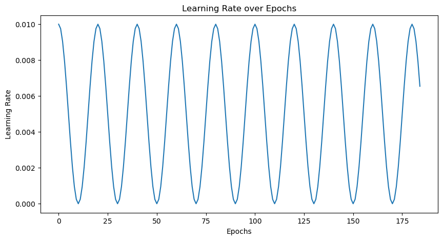

```python
# Assuming clf is your trained TabNetClassifier model
history = clf.history

# Plotting losses
plt.figure(figsize=(10, 5))
plt.plot(history['loss'], label='Training Loss')
plt.plot(history['validation_logloss'], label='Validation Loss')
plt.plot(history['train_logloss'], label='Train Loss')

# Assuming you have test loss
# plt.plot(history['test_loss'], label='Test Loss')
plt.xlabel('Epochs')
plt.ylabel('Loss')
plt.title('Training, Validation and Test Loss over Epochs')
plt.legend()
plt.show()

# Plotting learning rate
plt.figure(figsize=(10, 5))
plt.plot(history['lr'])
plt.xlabel('Epochs')
plt.ylabel('Learning Rate')
plt.title('Learning Rate over Epochs')
plt.show()
```

```python
explainability_matrix , masks = clf.explain(X_test.values)
```

```python
xticks = [0,  67022, 134045, 201067, 268090]
feature_names = X_train.columns.values
```

```python
fig, ax = plt.subplots(ncols=2, figsize=(100, 90))

# Plot mask for step 1 (Transpose using T)
sns.heatmap(masks[0].T, ax=ax[0], cmap='viridis', cbar=False)
ax[0].set_title('Mask for Step 1', fontsize=60)
ax[0].set_ylabel('Features', fontsize=45)
ax[0].set_xlabel('Samples', fontsize=45)
ax[0].set_xticks(xticks)
ax[0].set_xticklabels(xticks, fontsize=30)
ax[0].set_yticklabels(feature_names, fontsize=40, rotation=0.45)

# Plot mask for step 2 (Transpose using T)
sns.heatmap(masks[1].T, ax=ax[1], cmap='viridis', cbar_kws={"label": "Importance"})
ax[1].set_title('Mask for Step 2', fontsize=60)
ax[1].set_ylabel('Features', fontsize=45)
ax[1].set_xlabel('Samples', fontsize=45)
ax[1].set_xticks(xticks)
ax[1].set_xticklabels(xticks, fontsize=30)
ax[1].set_yticklabels(feature_names, fontsize=40, rotation=0.45)

cbar_ax.set_ylabel('Importance', size=45)
cbar_ax.yaxis.label.set_size(45)
plt.show()
```

[figure not shown]

```python
#Test Score
y_proba_dlt=clf.predict_proba(X_test.values)
y_pred_dlt= clf.predict(X_test.values)
y_proba_xgbt = best_xgb.predict_proba(X_test.values)
y_pred_xgbt = best_xgb.predict(X_test)
```

```python
print(f'''
Test Performance

TabNet Metrics
Log-Loss:{log_loss(y_test,y_proba_dlt)}

{classification_report(y_test,y_pred_dlt,target_names = label_encoder.classes_)}''')

print(f'''
XGB Metrics
Log-Loss:{log_loss(y_test,y_proba_xgbt)}

{classification_report(y_test,y_pred_xgbt,target_names = label_encoder.classes_)}''')
```

```
Test Performance

TabNet Metrics
Log-Loss:0.3397052111807903

              precision    recall  f1-score   support

 BAD BATTERY       0.78      0.80      0.79     92375
GOOD BATTERY       0.89      0.88      0.89    175716

    accuracy                           0.85    268091
   macro avg       0.84      0.84      0.84    268091
weighted avg       0.85      0.85      0.85    268091


XGB Metrics
Log-Loss:0.33283214915527204

              precision    recall  f1-score   support

 BAD BATTERY       0.83      0.73      0.78     92375
GOOD BATTERY       0.87      0.92      0.89    175716

    accuracy                           0.86    268091
   macro avg       0.85      0.83      0.84    268091
weighted avg       0.85      0.86      0.85    268091
```

```python
#Validation Scores
```

```python
y_proba_dl=clf.predict_proba(X_val.values)
y_pred_dl= clf.predict(X_val.values)
y_proba_xgb = best_xgb.predict_proba(X_val.values)
y_pred_xgb = best_xgb.predict(X_val)
```

```python
print(f'''
Validation Performance

TabNet Metrics
Log-Loss:{log_loss(y_val,y_proba_dl)}

{classification_report(y_val,y_pred_dl,target_names = label_encoder.classes_)}''')

print(f'''
XGB Metrics
Log-Loss:{log_loss(y_val,y_proba_xgb)}

{classification_report(y_val,y_pred_xgb,target_names = label_encoder.classes_)}''')
```

```
Validation Performance

TabNet Metrics
Log-Loss:0.33989103689821504

              precision    recall  f1-score   support

 BAD BATTERY       0.78      0.80      0.79     92375
GOOD BATTERY       0.89      0.88      0.89    175716

    accuracy                           0.85    268091
   macro avg       0.84      0.84      0.84    268091
weighted avg       0.85      0.85      0.85    268091


XGB Metrics
Log-Loss:0.33184180409800634

              precision    recall  f1-score   support

 BAD BATTERY       0.83      0.73      0.78     92375
GOOD BATTERY       0.87      0.92      0.89    175716

    accuracy                           0.86    268091
   macro avg       0.85      0.83      0.84    268091
weighted avg       0.86      0.86      0.85    268091
```

## Stacking

```python
import numpy as np

# Ensure your predicted probabilities are in numpy arrays
# This is needed because concatenation needs arrays
y_proba_dl_val = np.array(y_proba_dl)
y_proba_xgb_val = np.array(y_proba_xgb)

y_proba_dl_test = np.array(y_proba_dlt)
y_proba_xgb_test = np.array(y_proba_xgbt)
```

```python
# Convert probabilities to a DataFrame
prob_df = pd.DataFrame(y_proba_dl_val, columns=[f'prob_{i}' for i in range(y_proba_dl_val.shape[1])])
prob_xgb = pd.DataFrame(y_proba_xgb_val, columns=[f'prob_{i}' for i in range(y_proba_xgb_val.shape[1])])

# Reset indices of X_train (to ensure alignment when concatenating)
X_val = X_val.reset_index(drop=True)

# Concatenate probabilities with original data
X_val_with_probs = pd.concat([prob_df,prob_xgb], axis=1).values
```

```python
pd.DataFrame(X_val_with_probs)
```

|  | 0 | 1 | 2 | 3 |
| --- | --- | --- | --- | --- |
| 0 | 0.064554 | 0.935446 | 0.042998 | 0.957002 |
| 1 | 0.191056 | 0.808944 | 0.147886 | 0.852114 |
| 2 | 0.147596 | 0.852404 | 0.118236 | 0.881764 |
| 3 | 0.046153 | 0.953847 | 0.043121 | 0.956879 |
| 4 | 0.041136 | 0.958864 | 0.037462 | 0.962538 |
| ... | ... | ... | ... | ... |
| 268086 | 0.135198 | 0.864802 | 0.129562 | 0.870438 |
| 268087 | 0.584838 | 0.415162 | 0.526113 | 0.473887 |
| 268088 | 0.220780 | 0.779220 | 0.116594 | 0.883406 |
| 268089 | 0.108905 | 0.891095 | 0.128687 | 0.871313 |
| 268090 | 0.626669 | 0.373331 | 0.474231 | 0.525769 |

268091 rows × 4 columns

```python
# Predict probabilities from both classifiers on the test set

# Convert probabilities to a DataFrame
prob_df2 = pd.DataFrame(y_proba_dl_test, columns=[f'prob_{i}' for i in range(y_proba_dl_test.shape[1])])
prob_xgb2 = pd.DataFrame(y_proba_xgb_test, columns=[f'prob_{i}' for i in range(y_proba_xgb_test.shape[1])])

# Reset indices of X_train (to ensure alignment when concatenating)
X_test = X_test.reset_index(drop=True)

# Concatenate probabilities with original data
X_test_with_probs = pd.concat([prob_df2,prob_xgb2], axis=1).values
```

## Find best xgb meta learner

Here we use Optuna once again to optimize the hyper-parameters of an XGBoostClassifier. This time the classifier will serve as our 'Meta Learner', and will be trained on the predicted probabilites of the previous best XGB and best TabNet models. We then tell the Optuna api to perform a serach such that the best combination of hyperparameters is the combination that minimizes the log-loss on the test set, which in this case is being used as the 'validation' set. This ensure that our final meta learner has good generizablity.

```python
# Define the objective function for Optuna to optimize
def objective(trial):
    # Define the hyperparameter search space
    params = {
        "n_estimators": trial.suggest_int("n_estimators", 30, 400),
        "learning_rate": trial.suggest_float("learning_rate", 0.001, 1.0),
        "max_depth": trial.suggest_int("max_depth", 1, 5),
        "min_child_weight": trial.suggest_float("min_child_weight", 0.1, 10.0),
        "subsample": trial.suggest_float("subsample", 0.1, 1.0),
        "gamma": trial.suggest_float('gamma', 0.0, 1.0),
        "colsample_bytree": trial.suggest_float("colsample_bytree", 0.1, 1.0),
        "reg_alpha": trial.suggest_float("reg_alpha", 0.0, 10.0),
        "reg_lambda": trial.suggest_float("reg_lambda", 0.0, 10.0),
        "scale_pos_weight":  trial.suggest_float("scale_pos_weight",0,4)

    }

    # Create the XGBoost model with the suggested hyperparameters
    model = XGBClassifier(random_state=42, eval_metric='logloss',callbacks=[optuna.integration.XGBoostPruningCallback(trial, observation_key="validation_0-logloss")], **params)

    # Fit the model with hyperparameter tuning
    model.fit(X_val_with_probs, y_val, eval_set= [(X_test_with_probs,y_test)],verbose=0)

    # Evaluate the model
    y_proba = model.predict_proba(X_test_with_probs)
    loss = log_loss(y_test, y_proba)

    return loss


# Enable hyperband pruning with the number of trials set to 500
study = optuna.create_study(direction="minimize", pruner= HyperbandPruner(min_resource=50), study_name="xgb_hyperparameter_tuning")
study.optimize(objective, n_trials=2000, n_jobs=-1)
best_trial = study.best_trial
```

[output not shown]

[output cut: 1984 more lines]

```python
print(f'''Best Trial: {best_trial.number}
    Best Log-Loss: {best_trial.value}
    Best Params: {best_trial.params}''')
```

[output not shown]

```python
# Get the best hyperparameters found during the tuning process
best_params = study.best_params
print("Best Hyperparameters:", best_params)

# Train the final model with the best hyperparameters on the combined train and validation sets
best_model = XGBClassifier(random_state=42, **best_params)
best_model.fit(X_val_with_probs, y_val)

# Test the final model on a test dataset (replace X_test and y_test with your test data)
y_val_pred = best_model.predict_proba(X_val_with_probs)
logloss = log_loss(y_val, y_val_pred)
print("Validation Logloss:", logloss)
```

[output not shown]

```python
# Test the final model on a test dataset (replace X_test and y_test with your test data)
y_test_pred = best_model.predict_proba(X_test_with_probs)
logloss = log_loss(y_test, y_test_pred)
print("Test Logloss:", logloss)
```

```
Test Logloss: 0.3277673555026798
```

```python
best_meta_params = {'n_estimators': 218,
 'learning_rate': 0.037321332149121166,
 'max_depth': 5,
 'min_child_weight': 2.530752803314623,
 'subsample': 0.8971590202162913,
 'gamma': 0.11863869366534446,
 'colsample_bytree': 0.7482930647506527,
 'reg_alpha': 3.6900439203862,
 'reg_lambda': 0.8586623588920581,
 'scale_pos_weight': 1.003534153382244}
```

```python
#Create and fit meta learner

meta_model = XGBClassifier(random_state = 42,**best_meta_params)
meta_model.fit(X_val_with_probs, y_val,eval_set = [(X_test_with_probs,y_test)],verbose = 1)
```

```
XGBClassifier(base_score=None, booster=None, callbacks=None,
              colsample_bylevel=None, colsample_bynode=None,
              colsample_bytree=0.7482930647506527, early_stopping_rounds=None,
              enable_categorical=False, eval_metric=None, feature_types=None,
              gamma=0.11863869366534446, gpu_id=None, grow_policy=None,
              importance_type=None, interaction_constraints=None,
              learning_rate=0.037321332149121166, max_bin=None,
              max_cat_threshold=None, max_cat_to_onehot=None,
              max_delta_step=None, max_depth=5, max_leaves=None,
              min_child_weight=2.530752803314623, missing=nan,
              monotone_constraints=None, n_estimators=218, n_jobs=None,
              num_parallel_tree=None, predictor=None, random_state=42, ...)
```

```python
## Save Best Meta Learner. Run only of best_meta_model doesnt exist yet
#meta_model.save_model('best_meta_model.json')
```

```python
meta_model = XGBClassifier(random_state = 42)
meta_model.load_model('best_meta_model.json')
```

```python
m_proba = meta_model.predict_proba(X_val_with_probs)
m_pred = meta_model.predict(X_val_with_probs)
print(f'''
Validation Metrics
Log-Loss: {log_loss(y_val,m_proba)}

{classification_report(y_val,m_pred,target_names = label_encoder.classes_)}''')
```

```
Validation Metrics
Log-Loss: 0.3256579643317078

              precision    recall  f1-score   support

 BAD BATTERY       0.83      0.74      0.78     92375
GOOD BATTERY       0.87      0.92      0.90    175716

    accuracy                           0.86    268091
   macro avg       0.85      0.83      0.84    268091
weighted avg       0.86      0.86      0.86    268091
```

```python
m_proba = meta_model.predict_proba(X_test_with_probs)
m_pred = meta_model.predict(X_test_with_probs)
print(f'''
Test Metrics
Log-Loss: {log_loss(y_test,m_proba)}

{classification_report(y_test,m_pred,target_names = label_encoder.classes_)}''')
```

```
Test Metrics
Log-Loss: 0.3277629042764438

              precision    recall  f1-score   support

 BAD BATTERY       0.83      0.74      0.78     92375
GOOD BATTERY       0.87      0.92      0.90    175716

    accuracy                           0.86    268091
   macro avg       0.85      0.83      0.84    268091
weighted avg       0.86      0.86      0.86    268091
```

# Meta Learner Validation

## Combine dataset for final validation

```python
combined_data = pd.concat([X_train, X_val, X_test], ignore_index=True)
combined_labels = pd.concat([y_train,y_val,y_test],ignore_index=True)
```

## Get probabilities

```python
tabnet_val_proba =  clf.predict_proba(combined_data.values)
tabnet_val_preds =  clf.predict(combined_data.values)
```

```python
xgb_val_proba = best_xgb.predict_proba(combined_data.values)
xgb_val_preds = best_xgb.predict(combined_data.values)
```

```python
# Convert probabilities to a DataFrame
prob_df = pd.DataFrame(tabnet_val_proba, columns=[f'prob_{i}' for i in range(tabnet_val_proba.shape[1])])
prob_xgb = pd.DataFrame(xgb_val_proba, columns=[f'prob_{i}' for i in range(xgb_val_proba.shape[1])])

# Reset indices of X_train (to ensure alignment when concatenating)
X_val_probs = X_val.reset_index(drop=True)

# Concatenate probabilities with original data
X_val_probs = pd.concat([prob_df,prob_xgb], axis=1).values

meta_proba = meta_model.predict_proba(X_val_probs)
meta_preds = meta_model.predict(X_val_probs)
```

```python
print(f'''

Entire Data Set Performance (X_train + X_val + X_test):

{classification_report(combined_labels,meta_preds,target_names = label_encoder.classes_)}
Log-Loss {log_loss(combined_labels,meta_proba)}''')
```

```
Entire Data Set Performance (X_train + X_val + X_test):

              precision    recall  f1-score   support

 BAD BATTERY       0.84      0.74      0.79    615918
GOOD BATTERY       0.87      0.92      0.90   1171713

    accuracy                           0.86   1787631
   macro avg       0.85      0.83      0.84   1787631
weighted avg       0.86      0.86      0.86   1787631

Log-Loss 0.3219982195580508
```